# 2018 Mass Shootings

Arjun Vaghela

05/19/2021

## Summary

In 2018, the United States had a large number of shootings that caused many injuries and deaths. There were a total of 340 shootings that occurred during this year and a total of 373 people lost their lives. With numerous shootings happening during the year, Chicago seemed to be impacted the most as they had the most occurrences out of any other city. Within Chicago, there were a total of 122 injured due to the shootings along with 13 killed during 2018.

## Summary Table

With many cities and states finding themselves having to recover from these shootings, below you can find an aggregated table that shows which states have suffered the most in terms of people killed and injured in 2018.

| state | Deaths | Injured | Total |
| --- | --- | --- | --- |
| Alabama | 12 | 55 | 67 |
| Arizona | 4 | 5 | 9 |
| Arkansas | 7 | 17 | 24 |
| California | 50 | 136 | 186 |
| Colorado | 9 | 27 | 36 |
| Connecticut | 0 | 8 | 8 |
| Delaware | 5 | 0 | 5 |
| District of Columbia | 2 | 23 | 25 |
| Florida | 48 | 132 | 180 |
| Georgia | 3 | 33 | 36 |
| Illinois | 21 | 150 | 171 |
| Indiana | 10 | 27 | 37 |
| Kansas | 1 | 11 | 12 |
| Kentucky | 7 | 25 | 32 |
| Louisiana | 15 | 50 | 65 |
| Maryland | 13 | 31 | 44 |
| Massachusetts | 0 | 4 | 4 |
| Michigan | 10 | 28 | 38 |
| Minnesota | 1 | 14 | 15 |
| Mississippi | 1 | 17 | 18 |
| Missouri | 12 | 52 | 64 |
| Nebraska | 1 | 16 | 17 |
| Nevada | 3 | 15 | 18 |
| New Jersey | 4 | 54 | 58 |
| New Mexico | 5 | 4 | 9 |
| New York | 5 | 53 | 58 |
| North Carolina | 14 | 37 | 51 |
| Ohio | 13 | 46 | 59 |
| Oklahoma | 2 | 19 | 21 |
| Pennsylvania | 35 | 63 | 98 |
| South Carolina | 5 | 19 | 24 |
| Tennessee | 19 | 68 | 87 |
| Texas | 29 | 62 | 91 |
| Utah | 0 | 4 | 4 |
| Virginia | 2 | 17 | 19 |
| Washington | 4 | 9 | 13 |
| Wisconsin | 1 | 16 | 17 |

From this table, you can see how different states were impacted based on the on the total amount of injured and killed people.

## Parkland Shooting

On February 14, 2018, Nikolas Cruz opened fire at Marjory Stoneman Douglas High School in Pompano Beach (Parkland), Florida. Reports say that the coordinate points for the shooting were around (26.3108, -80.2532249), which confirms that it was indeed on the school premises. This tragedy ended up impacting many people and in total, Cruz ended up killing 17 and injuring 17 students and staff. According to NBC News, Cruz had reportedly been expelled from the high school and was enrolled at another school at the time of the shooting. This shooting was was arguably the largest shooting in history and even President Donald Trump tweeted that there were “many signs the Florida shooter was mentally disturbed” (https://www.nbcnews.com/news/us-news/police-respond-shooting-parkland-florida-high-school-n848101).

## Interactive Map

[interactive chart not shown]

Above you will find an interactive map that shows the shootings that had occurred during 2018. As you hover over the different markers, you will find information about each shooting. The Parkland shooting described earlier is shown with the largest circle on the map as it was the largest shooting in 2018, followed by other large circles that represent other large shootings.

## States with Highest Shootings (Bar Graph)

With many students going out of state for college, safety is one of the main concerns that people take into account. Many people wonder which states are the most prone to gun violence and below you will find a graph that includes the top 6 states with the highest amount of deaths due to shootings in 2018.

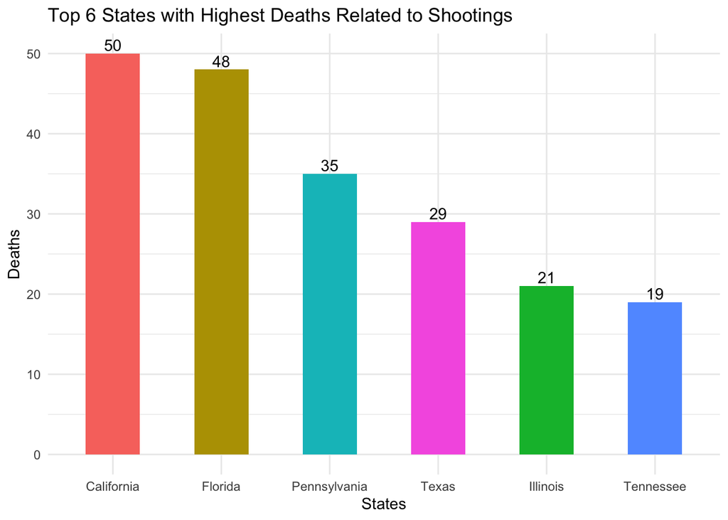

As shown in the chart above, California and Florida were the two highest ranked states in terms of deaths and injured people due to gun violence. With California having 50 deaths and Florida have 48 deaths in 2018, we can infer that these two states have the highest chance of people being killed in shootings. We can also see that within the top 6 highest death states, Tennessee (19 deaths) and Illinois (21 deaths) had a large difference in deaths related to shootings compared to California and Illinois.